# Capstone Project

rgeos

July 21, 2015

# 1. Introduction

The first step in building a predictive model for text is understanding the distribution and relationship between the words, tokens, and phrases in the text. The goal of this task is to perform some level of exploratory analysis and to understand the basic relationships observed in the data. Some of the necessary libraries are already loaded in the background (e.g `knitr, tm, RWeka, openNLP` etc…)

# 2. Tasks to accomplish

## 2.1. Exploratory analysis

I will comment out the following command since this may not work for you as it does for me. Please change the directory name to fit your needs and comment out the line. As a prerequisite, you should already have the 3 data files (English version) in your working directory. This will show the 3 files with data in English that we will be working with.

```r
# setwd("capstone_data/")
list_files = dir(pattern = "en_US*")
list_files
```

```
## [1] "en_US.blogs.txt"   "en_US.news.txt"    "en_US.twitter.txt"
```

We will determine the size of the files using a Linux system call of the command `du` or “disk usage”. The following function will show the size in Megabytes for all files in `list_files`. As an alternative, you could use R to show the size in Megabytes like: `file.info("path/to/the/file")$size / 1024^2`. The result will be the same.

```r
cat(
  sapply(
    list_files,
    function(x)
      {
        system(paste("du -kh",x), intern = TRUE)
      }
    )
  ) # size of each file
```

```
## 200M en_US.blogs.txt 196M    en_US.news.txt 159M en_US.twitter.txt
```

Another system call to identify the number of lines (`-l`), how many words (`-w`) and how many characters (`-c`) does each file in the `list_files` have. Please note that the options for the system call command may be different based on the flavor of the `*nix`.

```r
cat(
  sapply(
    list_files,
    function(x)
      {
        system(paste("wc -lwc",x), intern = TRUE)
      }
    )
  ) # number of lines, words, characters in this order for each file
```

```
##   899288 37334682 210159576 en_US.blogs.txt  1010242 34372710 205811835 en_US.news.txt  2360148 30374197 167105257 en_US.twitter.txt
```

## 2.2. Word frequencies

Perform some analysis on the first 5000 lines from each file. First load the lines and combine them in one sample text variable.

```r
blogs   = readLines(list_files[1], 5000)
news    = readLines(list_files[2], 5000)
twitter = readLines(list_files[3], 5000)

sample_text = paste(blogs, news, twitter)
sample_text = sent_detect(sample_text, language = "en") # this may take some time
```

Once the lines are loaded, we will perform some text mining operations on it, such as removing stop words (since the text is in English we will limit only to that), remove punctuation, numbers and white spaces.

```r
sample_corpus = VCorpus(VectorSource(sample_text))
sample_corpus = tm_map(sample_corpus, content_transformer(tolower))
sample_corpus = tm_map(sample_corpus, removeWords, stopwords(kind = "en"))
sample_corpus = tm_map(sample_corpus, removePunctuation)
sample_corpus = tm_map(sample_corpus, removeNumbers)
sample_corpus = tm_map(sample_corpus, stripWhitespace)
```

With the sample corpus created, we will move on to creating a term matrix. We would like to see what are the most frequent words (e.g. more than 200 times) showing in our sample corpus.

```r
docMarix = TermDocumentMatrix(sample_corpus, control = list(minWordLength = 5))
frequent_terms = findFreqTerms(docMarix, lowfreq = 200)
frequent_terms
```

```
## [1] "will"
```

The current sample corpus will be changed into a data.frame type before proceeding with the Weka backed analysis.

```r
sample_data_frame = data.frame(text = unlist(sapply(sample_corpus, '[', "content")), stringsAsFactors = FALSE)
```

Next we will create tokens for n-gram frequencies (2, 3 or multiple words).

```r
token = function(data, size)
{
  ngram           = NGramTokenizer(data, Weka_control(min=size, max=size, delimiters = " \\t\\r\\n.!?,;\"()"))
  word            = data.frame(table(ngram))
  sorted          = word[order(word$Freq, decreasing=T),]
  colnames(sorted) = c("Item", "Count")
  sorted
}

one   = token(sample_data_frame,1)
two   = token(sample_data_frame,2)
three = token(sample_data_frame,3)
```

Once the tokens are created, a nice way to visualize it is the cloud of words representation.

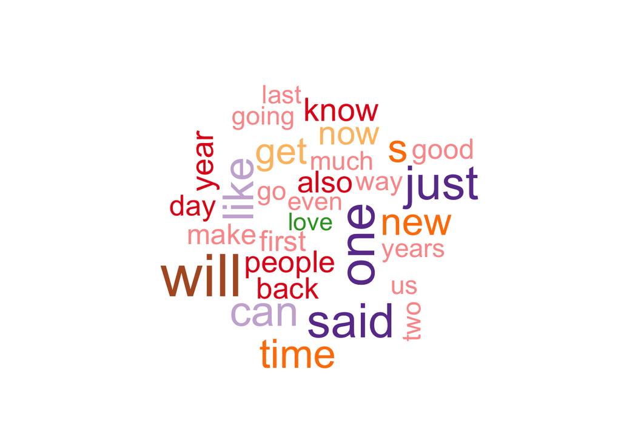

```r
prettycloud = function(data,frequency = 1,count = 10)
{
  wordcloud(data[,1][1:count], data[,2][1:count], min.freq = frequency, random.order = T, colors = brewer.pal(12,"Paired"), ordered.colors = F)
}
prettycloud(one,10,30)
```

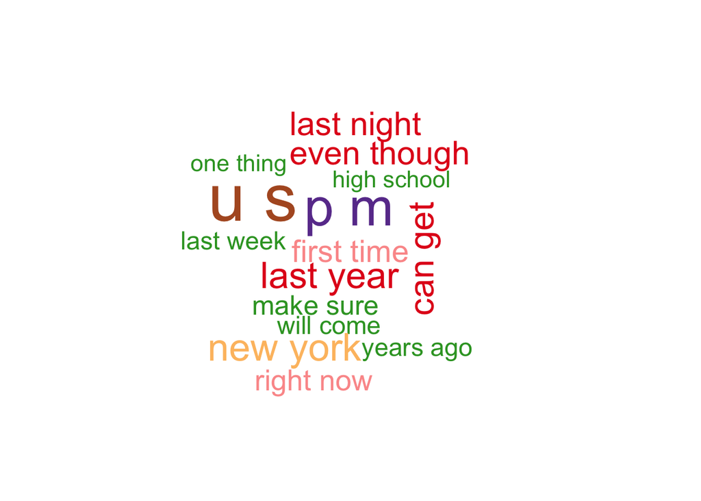

```r
prettycloud(two,1,15)
```